# SimpleLink™ CC1312R7 LaunchPad™ Settings & Resources

The [**SimpleLink CC1312R7 LaunchPad**](http://www.ti.com/tool/LP-CC1312R7) contains a [**CC1312R7**](http://www.ti.com/product/CC1312R7) device.

## Jumper Settings

- Close the **`LEDs`** jumper to enable the on-board LEDs.
- Close the **`RXD<<`** and **`TXD>>`** jumpers to enable UART via the XDS110 on-board USB debugger.

## SysConfig Board File

The LP_CC1312R7.syscfg.json is a handcrafted file used by SysConfig. It describes the physical pin-out and components on the LaunchPad.

## Driver Examples Resources

Examples utilize SysConfig to generate software configurations into the **ti_drivers_config.c** and **ti_drivers_config.h** files. The SysConfig user interface can be utilized to determine pins and resources used. Information on pins and resources used is also present in both generated files.

## TI BoosterPacks™

The following BoosterPack(s) are used with some driver examples.

#### [**BOOSTXL-SHARP128 LCD & SD Card BoosterPack**](http://www.ti.com/tool/boostxl-sharp128)

- No modifications are needed.

#### [**BP-BASSENSORSMKII BoosterPack**](http://www.ti.com/tool/bp-bassensorsmkii)

- No modifications are needed.

#### [**CC3200 Audio BoosterPack**](http://www.ti.com/tool/CC3200AUDBOOST)

- The BoostPack’s `DIN` signal pin is not compatible with this LaunchPad. Use one of the following modification(s) to enable the CC3200 Audio BoosterPack’s usage with the **i2secho** example.
- Bend down the pin between `DIO1` and `DIO30`. Be sure that the bent pin does not make contact with the IC or any other component, bend it enough to make sure it doesn’t connect to the CC3200 Audio BoosterPack.
- Attach the CC3200 Audio BoosterPack to the LP_CC1312R7
- Connect a jumper wire between `P3.3` and `P3.9` on the CC3200 Audio BoosterPack.
- See [Audio BP User Guide](http://www.ti.com/lit/pdf/swru383), Figure 2-1 for information on where these pins are located.
- See below for a diagram.

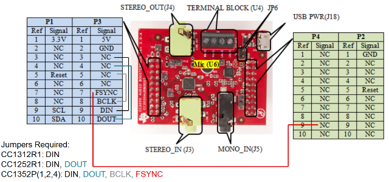